# Forecasting Swiss EV Registrations

Yuri Kim and Laura Ríos-Quiroz

2026-05-05

## Motivation, main findings and structure of the report

The rapid growth of electric vehicles in Switzerland creates new challenges for energy and transport infrastructure planning. For the Swiss Federal Office of Energy (SFOE), monthly EV registration forecasts are useful because future charging infrastructure needs depend on how quickly the number of battery electric vehicles increases. A forecast of EV registrations can therefore provide an early signal of future charging demand and help support investment decisions for public charging stations.

Our analysis suggests that EV registrations are likely to continue increasing in 2026. This result is mainly explained by the strong upward trend observed in recent years and by recurring seasonal patterns in the monthly registration data. In particular, the forecast indicates that some months are likely to experience higher registration levels than others, which is relevant for short-term infrastructure planning. Although oil prices were considered as a potential external factor, they did not improve the forecast performance in our model. This suggests that the future path of EV registrations is better captured by historical growth and seasonality than by oil price movements.

Therefore, our recommendation is that SFOE should increase its planned charging infrastructure investment for 2026. The forecast indicates that EV registrations are likely to continue rising and may reach new peak levels, which implies higher pressure on public charging capacity. The temporary slowdown observed in 2024 should not be treated as evidence of a lasting decline in EV adoption. Instead, SFOE should use the forecast as a signal to bring forward infrastructure investment and ensure that charging capacity expands in line with expected EV growth.

## 01. Raw Data Visualization

```r
#rawData <- read.csv("../data_raw/Filtered_data.csv", header = TRUE)
rawData <- read.csv("../scripts/Filtered_data.csv", header = TRUE)
#ncol(rawData)
#nrow(rawData)
#colnames(rawData)

data <- ts(rawData$OBS_VALUE,start = c(2005,1), frequency = 12)
#frequency(data)
#tsp(data)
```

### Visualize the data

For our analysis, we forecast monthly electric vehicle registrations in Switzerland. We clearly observe a strong upward trend in EV registrations, especially in recent years, reflecting the rapid adoption of electric vehicles in Switzerland. In addition, several important observations can be made from the time series data.

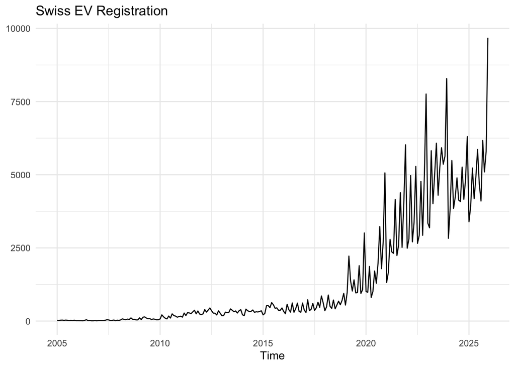

```r
g <- autoplot(data) +
  ggtitle("Swiss EV Registration") +
  ylab("No. of EV") +
  theme_minimal() +
  theme(legend.title = element_blank()) +  # Remove legend title
  theme(axis.title.y = element_blank())  # Remove vertical axis label
g
```

```r
#ggsave("../graphs/EV_registration_visualization.png", plot = g, width = 8, height = 5, dpi = 300)
```

**There are a few observations we can make from the graph:**

- **Observation 1**: The graph shows a clear upward trend in the number of EV registrations after around year 2020. This means that the data is not stationary (non stationary mean), and we will need to apply transformations such as differencing to make it suitable for modeling.
- **Observation 2**: Another feature is the graph fluctuates more in the later years, which suggests that the variance is not constant over time (non stationary variance). This means that we may need to apply a transformation such as a log transformation to stabilize the variance before modeling.  
  Now, to see if the data has a seasonal pattern, we can create a seasonal plot. This will help us visualize any recurring patterns or cycles in the data that occur at regular intervals.

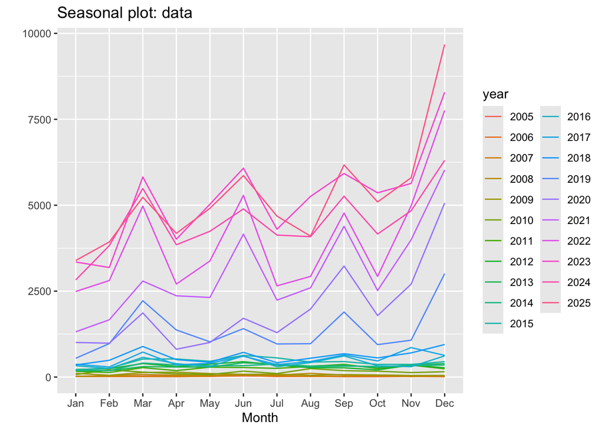

```r
season_plot <- ggseasonplot(data)
season_plot
```

```r
#ggsave("../graphs/seasonal_EV_registration_visualization.png", plot = season_plot, width = 8, height = 5, dpi = 300)
```

## 02. Data Preprocessing

Before we can apply any forecasting models, we need to preprocess the data to ensure that it is suitable for modeling. This involves applying transformations to stabilize the variance, such as a log transformation, and applying differencing to remove any trends or seasonality in the data. We will also visualize the transformed data to confirm that the transformations have been effective in making the data more stationary and suitable for modeling. and finally check the stationarity of the transformed data using statistical tests such as the Augmented Dickey-Fuller (ADF) test to confirm that the data is now stationary and ready for modeling.

### Log Transformation

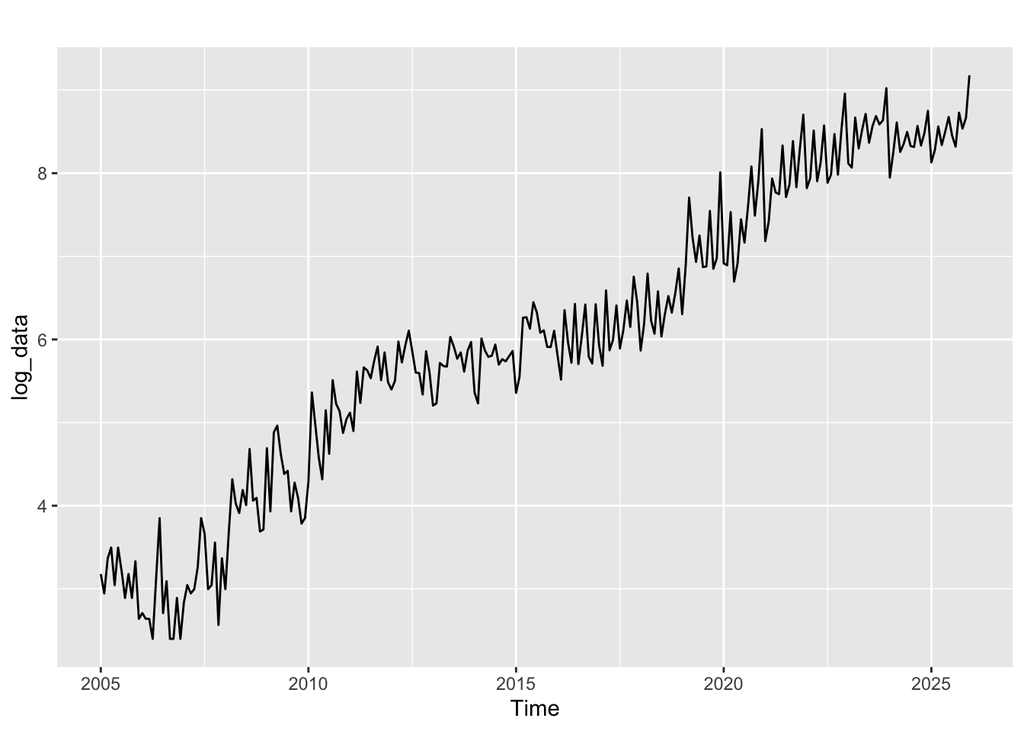

```r
log_data <- log(data)
log_g <- autoplot(log_data)
log_g
```

After the log transformation, the variability appears more consistent across the entire time period, suggesting the log transformation effectively compresses the scale of the data, particularly in the later years where the values are higher, resulting in a more homoscedastic series that is better suited for modeling.

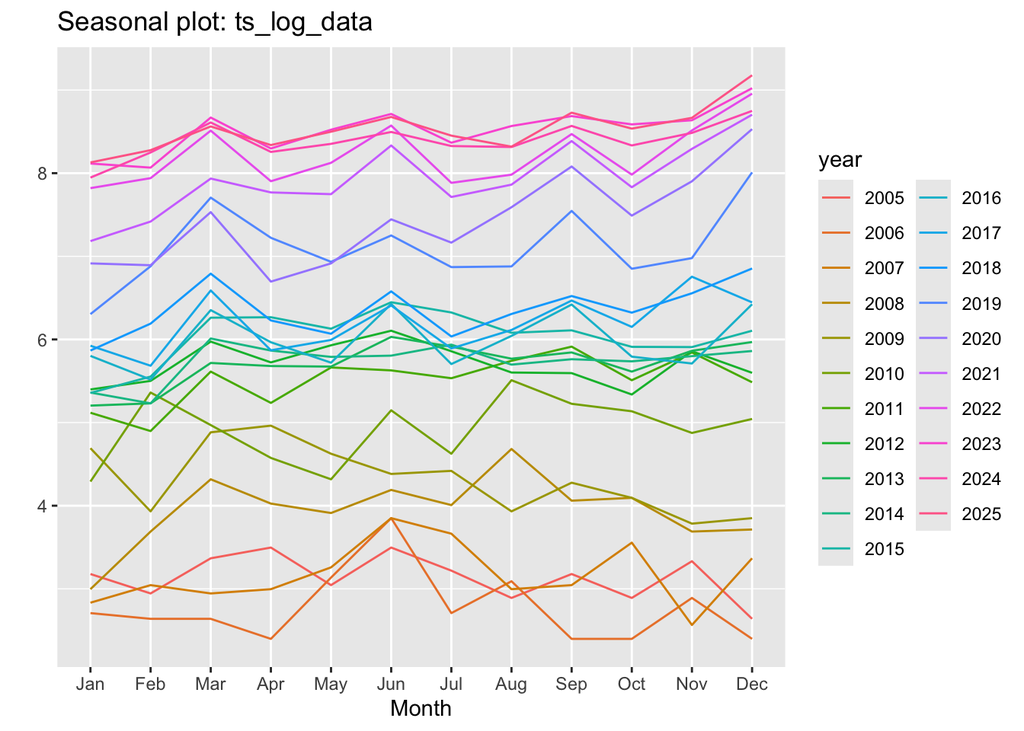

```r
ts_log_data <- ts(log_data, start = c(2005,1), frequency = 12)
season_plot <- ggseasonplot(ts_log_data)
season_plot
```

However, the upwards trend and the seasonality are still present in the log-transformed data, which indicates that further transformations are needed to achieve stationarity. To address this, we will apply differencing to remove the trend and seasonality from the data.

### Seasonal Differencing

Seasonal differencing with a lag of 12 was performed to remove the annual pattern inherent in the monthly data. This step accounts for recurring seasonal effects by comparing each observation to its value in the same month of the previous year.

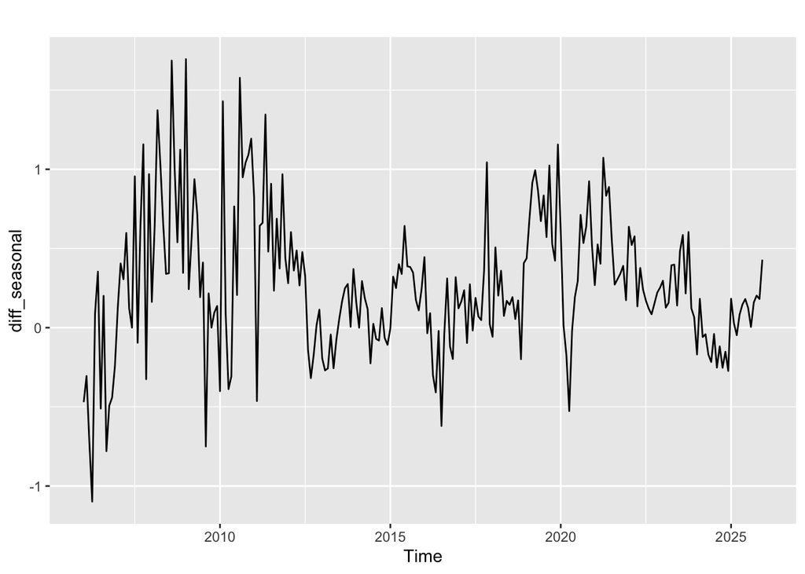

```r
diff_seasonal <- diff(log_data, lag=12)
df_s_g <- autoplot(diff_seasonal)
df_s_g
```

After applying seasonal differencing (lag = 12), the series appears to fluctuate around a relatively constant mean with no clear upward or downward trend. This suggests that the seasonal differencing has largely removed both the seasonal component.  
To further examine wether additional differencing is required, we used the autocorrelation function (ACF) plot of the seasonally differenced series.

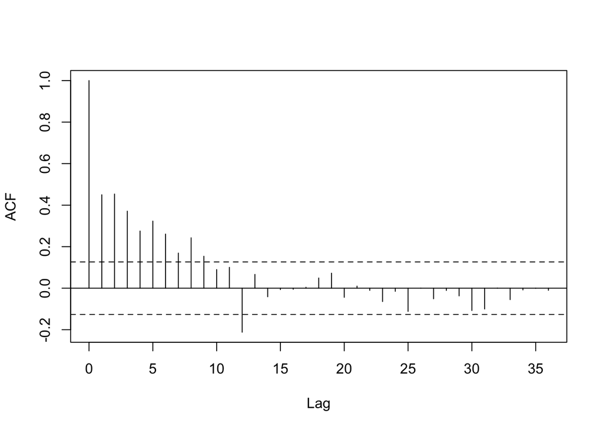

```r
acf_values <- acf(diff_seasonal, lag.max = 36, plot = FALSE)

n <- length(diff_seasonal)
ci <- 1.96 / sqrt(n)

plot(
  acf_values$lag * frequency(diff_seasonal),
  acf_values$acf,
  type = "h",
  xlab = "Lag",
  ylab = "ACF"
)
abline(h = 0)
abline(h = c(-ci, ci), lty = 2)
```

After applying seasonal differencing (lag = 12), the autocorrelation function still exhibits a slow decay, with significant correlations persisting across multiple lags. This pattern indicates that the series remains non-stationary, suggesting the presence of a remaining trend component.

### Regular Differencing

Therefore, a first-order regular differencing was applied to remove the remaining trend and achieve stationarity.

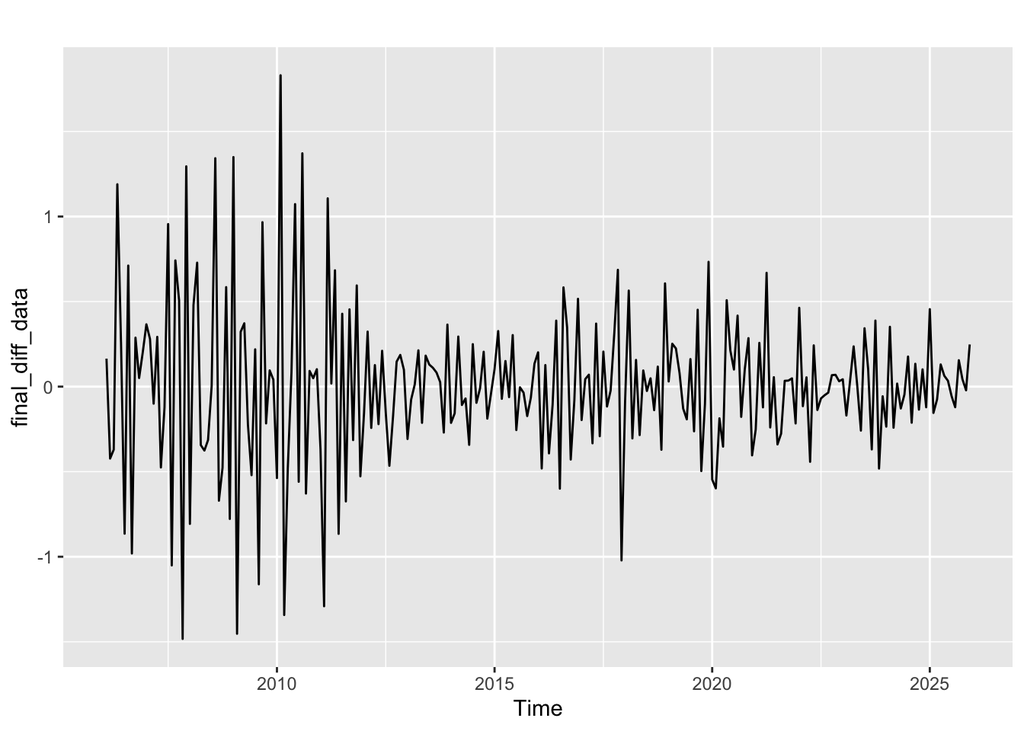

```r
final_diff_data <- diff(diff_seasonal)
df_g <- autoplot(final_diff_data)
df_g
```

And once again, we checked the ACF plot to confirm that the series is now stationary.

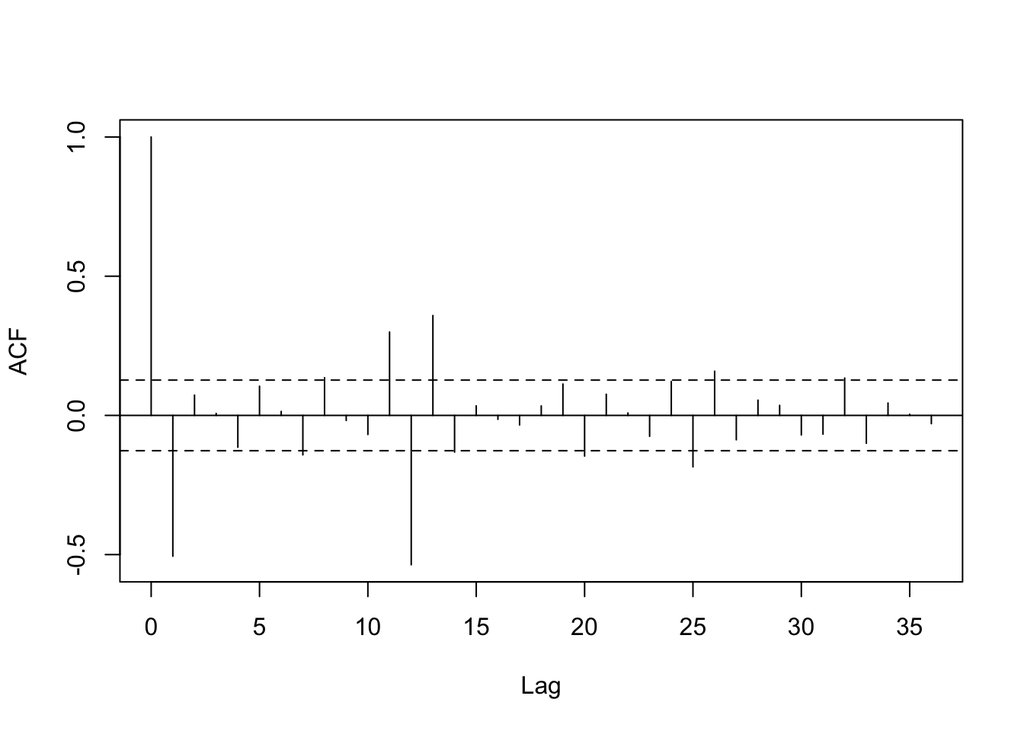

```r
acf_values <- acf(final_diff_data, lag.max = 36, plot = FALSE)

n <- length(final_diff_data)
ci <- 1.96 / sqrt(n)

plot(
  acf_values$lag * frequency(final_diff_data),
  acf_values$acf,
  type = "h",
  xlab = "Lag",
  ylab = "ACF"
)
abline(h = 0)
abline(h = c(-ci, ci), lty = 2)
```

After applying log transformation, seasonal differencing with lag 12, and first-order regular differencing, the transformed series no longer shows a clear trend or repeated seasonal pattern. The ACF also suggests that most autocorrelations fall within the confidence bounds, indicating that the mean structure has been largely stabilized.

However, the time plot of the transformed series shows that the early period still has noticeably higher volatility than the later period. Therefore, the transformed series may not be strictly stationary in terms of variance. For this reason, the series should be interpreted as approximately stationary rather than perfectly stationary, and the remaining volatility instability should be acknowledged as a limitation of the SARIMA modeling approach.

As shown in the ACF plot, there is a significant negative spike at lag 1, suggesting a possible non-seasonal MA(1) component. In addition, a significant spike appears at the seasonal lag 12, which suggests a possible seasonal MA(1) component. Therefore, q=1 and Q=1 were considered as reasonable candidate values for the SARIMA specifications.

Furthermore, the partial autocorrelation function (PACF) was examined To determine a suitable value for p, using the transformed stationary series.

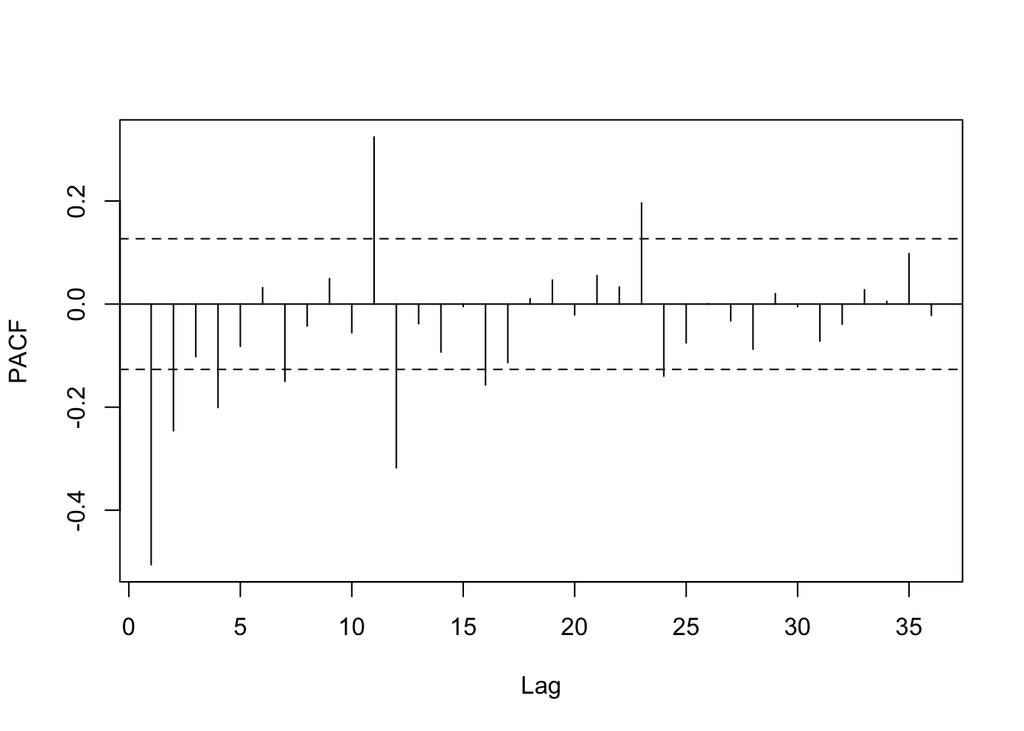

```r
pacf_values <- pacf(final_diff_data, lag.max = 36, plot = FALSE)

n <- length(final_diff_data)
ci <- 1.96 / sqrt(n)

plot(
  pacf_values$lag * frequency(final_diff_data),
  pacf_values$acf,
  type = "h",
  xlab = "Lag",
  ylab = "PACF"
)
abline(h = 0)
abline(h = c(-ci, ci), lty = 2)
```

The PACF plot shows a significant spike at lag 1, suggesting a possible non-seasonal AR(1) component. Since some additional early-lag partial autocorrelations are also significant, p=1 and p=2 were considered as candidate values. In addition, the significant spike around the seasonal lag 12 suggests a possible seasonal AR(1) component, so P=1 was considered as a candidate for the SARIMA specifications.

## 02. Modeling

### SARIMA Model

SARIMA was used because the EV registration data are observed at a monthly frequency and show evidence of annual seasonality. The significant spikes around lag 12 in the ACF and PACF also suggest that the series contains seasonal dependence, which cannot be fully captured by a standard non-seasonal ARIMA model. Therefore, SARIMA is more suitable for modelling both non-seasonal and seasonal patterns in the data.

As discussed above, the ACF suggests q=1 as a reasonable non-seasonal MA candidate, while the PACF suggests p=1 or p=2 as reasonable non-seasonal AR candidates. Since first-order differencing was applied to achieve stationarity, the differencing order was set to d=1.

For the seasonal components, the significant spikes around lag 12 in the ACF and PACF suggest possible seasonal MA(1) and AR(1) components, respectively. Therefore, Q=1 and P=1 were considered as candidate seasonal orders. Since seasonal differencing was also applied to remove annual seasonality, D=1 was used. Based on these candidate values, two SARIMA specifications were estimated and compared to identify the most appropriate model.

```r
# Split the data into training and testing sets
train <- window(data, end=c(2024,12))
test  <- window(data, start=c(2025,1))

# Apply log transformation to stabilize the variance
log_train <- log(train)
log_test  <- log(test)


# Fit the first candidate SARIMA model on the training data
# Non-seasonal order: p = 1, d = 1, q = 1
# Seasonal order: P = 1, D = 1, Q = 1
# Seasonal period: 12, because the data are monthly
sarima_1 <- Arima(
  log_train,
  order = c(1, 1, 1),
  seasonal = c(1, 1, 1)
)

# Fit the second candidate SARIMA model on the training data
# This model uses p = 2 instead of p = 1,
# because the PACF suggested p = 1 or p = 2 as possible candidates
sarima_2 <- Arima(
  log_train,
  order = c(2, 1, 1),
  seasonal = c(1, 1, 1)
)


# Forecast the test period
# h should be equal to the length of the test set
h <- length(log_test)

forecast_1 <- forecast(sarima_1, h = h)
forecast_2 <- forecast(sarima_2, h = h)

# Compare forecast accuracy on the log scale
accuracy_1 <- accuracy(forecast_1, log_test)
accuracy_2 <- accuracy(forecast_2, log_test)

# Create a comparison table using AIC, BIC, RMSE, and MAE
model_comparison <- data.frame(
  Model = c(
    "SARIMA(1,1,1)(1,1,1)[12]",
    "SARIMA(2,1,1)(1,1,1)[12]"
  ),
  AIC = c(AIC(sarima_1), AIC(sarima_2)),
  BIC = c(BIC(sarima_1), BIC(sarima_2)),
  RMSE = c(accuracy_1["Test set", "RMSE"], accuracy_2["Test set", "RMSE"]),
  MAE = c(accuracy_1["Test set", "MAE"], accuracy_2["Test set", "MAE"])
)

# Sort models by test RMSE
model_comparison <- model_comparison[order(model_comparison$RMSE), ]

# Display the model comparison table
model_comparison
```

|  | Model | AIC | BIC | RMSE | MAE |
| --- | --- | --- | --- | --- | --- |
| 2 | SARIMA(2,1,1)(1,1,1)[12] | 137.6614 | 158.2111 | 0.1040060 | 0.09376886 |
| 1 | SARIMA(1,1,1)(1,1,1)[12] | 135.8342 | 152.9590 | 0.1046708 | 0.09388619 |

### Baseline Model

To evaluate whether the SARIMA model improves forecasting performance beyond simple benchmarks, it was compared with three baseline models: the mean forecast, the naive forecast, and the seasonal naive forecast. The seasonal naive model is particularly relevant because the data are monthly and may contain annual seasonal patterns. Each model was fitted using the training data and evaluated on the same test set using RMSE and MAE.

```r
# Set forecast horizon equal to the length of the test set
h <- length(log_test)

# -------------------------------
# 1. Baseline models
# -------------------------------

# Mean forecast: uses the average of the training data
mean_fc <- meanf(log_train, h = h)

# Naive forecast: uses the last observed value as the forecast
naive_fc <- naive(log_train, h = h)

# Seasonal naive forecast: uses the value from the same month in the previous year
snaive_fc <- snaive(log_train, h = h)

# -------------------------------
# 2. Final SARIMA model
# -------------------------------

# Fit the selected SARIMA model on the training data
# SARIMA(1,1,1)(1,1,1)[12]
sarima_final <- Arima(
  log_train,
  order = c(1, 1, 1),
  seasonal = c(1, 1, 1)
)

# Forecast the test period
sarima_fc <- forecast(sarima_final, h = h)

# -------------------------------
# 3. Compare forecast accuracy
# -------------------------------

# Calculate accuracy measures on the test set
mean_acc   <- accuracy(mean_fc, log_test)
naive_acc  <- accuracy(naive_fc, log_test)
snaive_acc <- accuracy(snaive_fc, log_test)
sarima_acc <- accuracy(sarima_fc, log_test)

# Create comparison table
baseline_comparison <- data.frame(
  Model = c(
    "Mean forecast",
    "Naive forecast",
    "Seasonal naive forecast",
    "SARIMA(2,1,1)(0,1,1)[12]"
  ),
  RMSE = c(
    mean_acc["Test set", "RMSE"],
    naive_acc["Test set", "RMSE"],
    snaive_acc["Test set", "RMSE"],
    sarima_acc["Test set", "RMSE"]
  ),
  MAE = c(
    mean_acc["Test set", "MAE"],
    naive_acc["Test set", "MAE"],
    snaive_acc["Test set", "MAE"],
    sarima_acc["Test set", "MAE"]
  )
)

# Sort by RMSE
baseline_comparison <- baseline_comparison[order(baseline_comparison$RMSE), ]

# Display the comparison table
baseline_comparison
```

|  | Model | RMSE | MAE |
| --- | --- | --- | --- |
| 4 | SARIMA(2,1,1)(0,1,1)[12] | 0.1046708 | 0.09388619 |
| 3 | Seasonal naive forecast | 0.1815954 | 0.14732393 |
| 2 | Naive forecast | 0.3402356 | 0.29059510 |
| 1 | Mean forecast | 2.6857012 | 2.67306072 |

### Residual diagnostics

Residual diagnostics were conducted to assess whether the selected SARIMA model adequately captured the autocorrelation structure of the series.

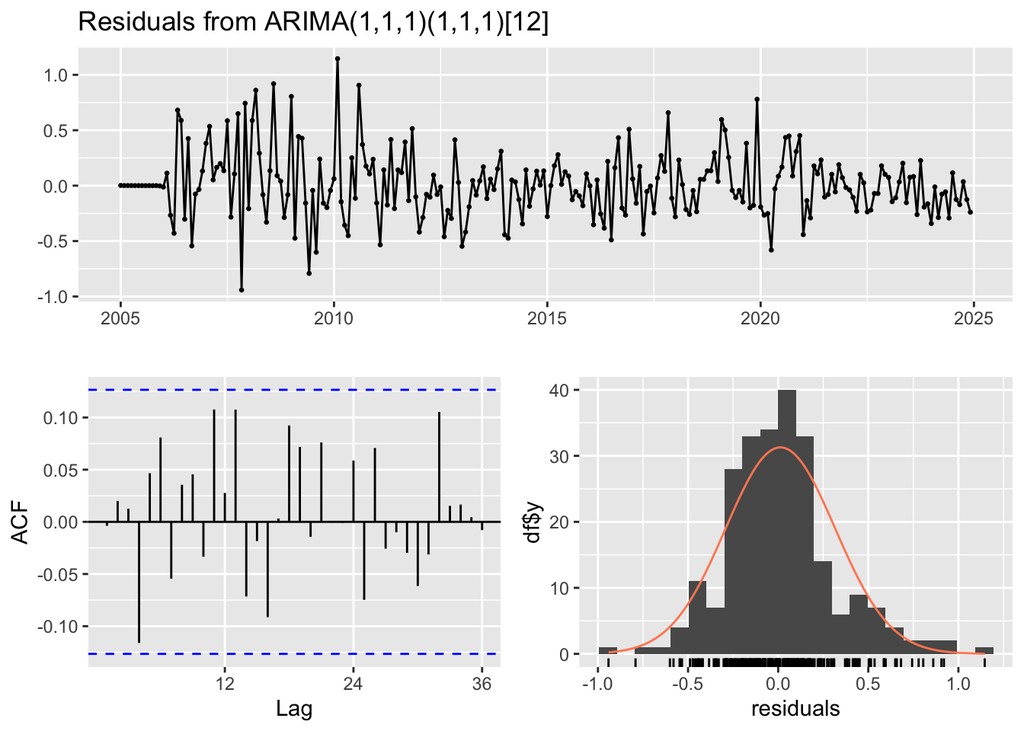

```
##
##  Ljung-Box test
##
## data:  Residuals from ARIMA(1,1,1)(1,1,1)[12]
## Q* = 23.241, df = 20, p-value = 0.2771
##
## Model df: 4.   Total lags used: 24
```

```r
# Residual diagnostics for the selected SARIMA model
checkresiduals(sarima_final)
```

The residuals fluctuate around zero without a clear remaining trend or seasonal pattern. The residual ACF shows that most autocorrelations lie within the 95% confidence bounds. In addition, the Ljung-Box test produced a p-value of 0.2771, which is greater than 0.05. Therefore, we fail to reject the null hypothesis of no autocorrelation in the residuals. This suggests that the residuals are approximately white noise and that the SARIMA model provides an adequate fit.

## 03. Exogenous variable extension

To examine whether external factors improve the forecast, an extended SARIMA model with exogenous regressors was also considered. Oil price was used as a potential explanatory variable because higher oil costs may affect incentives for electric vehicle adoption. The model was estimated using the same SARIMA structure, but with the exogenous variable included through the xreg term. Its forecasting performance was then compared with the best SARIMA model using RMSE and MAE.

```r
#oil_raw <- read.csv("../data_raw/oil_price(2005-2025).csv", header = TRUE)
oil_raw <- read.csv("../scripts/oil_price(2005-2025).csv", header = TRUE)
# Create the time series object for oil
oil_ts <- ts(oil_raw$MCOILBRENTEU, start = c(2005, 1), frequency = 12)

# Transformation: Log and Difference (same as we did with the EVs)
log_oil <- log(oil_ts)

# Split into train and test sets
oil_train <- window(log_oil, end = c(2024, 12))
oil_test  <- window(log_oil, start = c(2025, 1))

h <- length(log_test)

# Fit SARIMAX model
sarimax_oil <- Arima(
  log_train,
  order = c(1, 1, 1),
  seasonal = c(1, 1, 1),
  xreg = oil_train
)

# Forecast using future/test-period xreg values
sarimax_oil_fc <- forecast(
  sarimax_oil,
  h = h,
  xreg = oil_test
)

# Existing SARIMA forecast accuracy
sarima_fc <- forecast(sarima_final, h = h)
sarima_acc <- accuracy(sarima_fc, log_test)

# SARIMAX forecast accuracy
sarimax_acc <- accuracy(sarimax_oil_fc, log_test)

comparison <- data.frame(
  Model = c(
    "SARIMA(1,1,1)(1,1,1)[12]",
    "SARIMAX with fuel price"
  ),
  RMSE = c(
    sarima_acc["Test set", "RMSE"],
    sarimax_acc["Test set", "RMSE"]
  ),
  MAE = c(
    sarima_acc["Test set", "MAE"],
    sarimax_acc["Test set", "MAE"]
  ),
  AIC = c(
    AIC(sarima_final),
    AIC(sarimax_oil)
  ),
  BIC = c(
    BIC(sarima_final),
    BIC(sarimax_oil)
  )
)

comparison
```

| Model | RMSE | MAE | AIC | BIC |
| --- | --- | --- | --- | --- |
| SARIMA(1,1,1)(1,1,1)[12] | 0.1046708 | 0.09388619 | 135.8342 | 152.9590 |
| SARIMAX with fuel price | 0.1127149 | 0.09923949 | 136.6530 | 157.2027 |

As an extension, fuel price was included as an exogenous variable in a SARIMAX model to test whether external economic information could improve forecast accuracy. However, the SARIMAX model produced higher RMSE and MAE than the selected SARIMA model. Its AIC and BIC values were also higher, indicating that the additional exogenous variable did not improve the balance between model fit and complexity. Therefore, fuel price was not retained in the final forecasting model, and SARIMA(1,1,1)(1,1,1)[12] was selected as the final specification.

### Model Comparison and Key Insights.

The comparison above highlights a classic modeling dilemma: does adding more variables actually give us a clearer crystal ball? By contrasting our standard SARIMA against the oil-inclusive SARIMAX, we are looking at two distinct stories told by the metrics:

Is the extra complexity worth it? Metrics like AIC and BIC help us police our own model. They reveal if factoring in fuel prices provides a genuine breakthrough in explaining EV adoption trends, or if a simpler, endogenous approach is actually more robust against overfitting.

Does the real world match the math? If the oil price data is truly useful, we should see a noticeable drop in the test set’s RMSE and MAE. A more accurate SARIMAX would prove that Swiss car buyers are actively responding to energy market shocks when making the switch to electric mobility.

## 04. Final Forecasts

Finally, the selected SARIMA model was used to generate forecasts for the test period. The forecasts were then transformed back to the original scale by applying the exponential function, since the model was fitted on log-transformed data.

### Model fitting with the entire dataset

To generate forecasts for the future beyond the test period, the SARIMA model was re-fitted

```r
sarima_final_full <- Arima(
  log(data),
  order = c(1, 1, 1),
  seasonal = c(1, 1, 1)
)
```

### Future Forecasts

The fitted model was then used to forecast the next 12 months of EV registrations

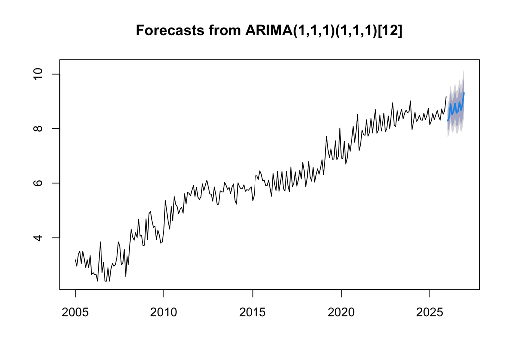

```r
# Forecast 12 months ahead
sarima_forecast <- forecast(sarima_final_full, h = 12)

# Plot forecast on log scale
plot(sarima_forecast)
```

### Reverse transformation to original scale

To interpret the forecasts in terms of the original number of EV registrations, the forecasts were transformed back to the original scale by applying the exponential function to the forecasted log values.

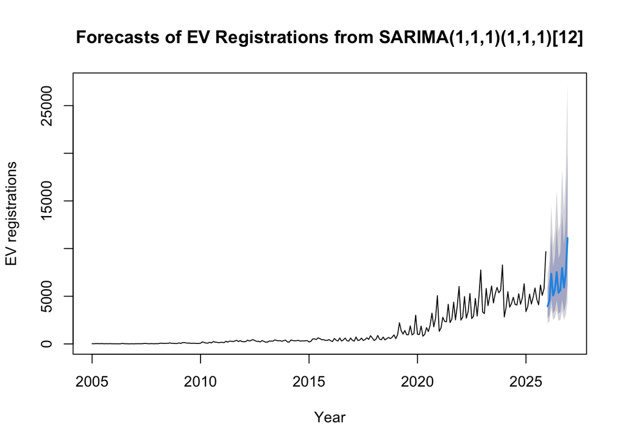

```r
# Back-transform the forecast from log scale to original scale
sarima_forecast_original <- sarima_forecast

sarima_forecast_original$x    <- exp(sarima_forecast$x)
sarima_forecast_original$mean <- exp(sarima_forecast$mean)
sarima_forecast_original$lower <- exp(sarima_forecast$lower)
sarima_forecast_original$upper <- exp(sarima_forecast$upper)

# Plot forecast on the original EV registration scale
plot(
  sarima_forecast_original,
  main = "Forecasts of EV Registrations from SARIMA(1,1,1)(1,1,1)[12]",
  ylab = "EV registrations",
  xlab = "Year"
)
```

```r
dev.copy(
  png,
  filename = "../graphs/sarima_forecast_ev_registrations.png",
  width = 1000,
  height = 700
)
```

### Forecast Table

The forecasted values for the next 12 months were also tabulated to provide a clear summary of the expected EV registrations in the future period.

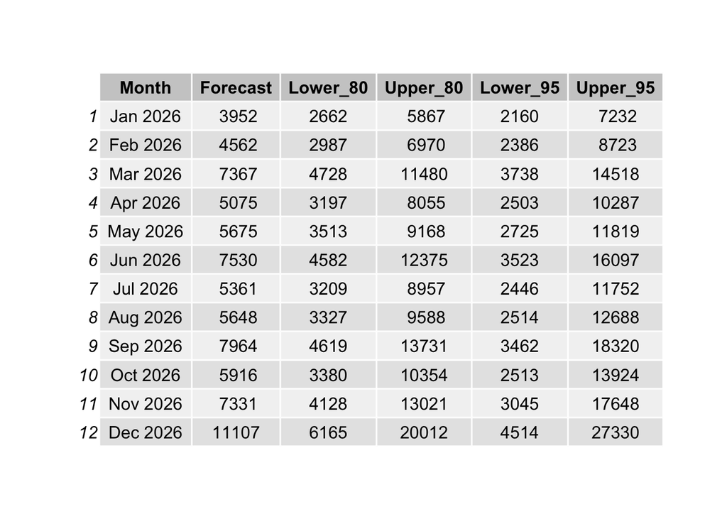

```r
  forecast_table <- data.frame(
  Month = as.yearmon(time(sarima_forecast_original$mean)),
  Forecast = round(as.numeric(sarima_forecast_original$mean)),
  Lower_80 = round(as.numeric(sarima_forecast_original$lower[, "80%"])),
  Upper_80 = round(as.numeric(sarima_forecast_original$upper[, "80%"])),
  Lower_95 = round(as.numeric(sarima_forecast_original$lower[, "95%"])),
  Upper_95 = round(as.numeric(sarima_forecast_original$upper[, "95%"]))
)

grid.table(forecast_table)
```

```r
# Copy the current table output to PNG
dev.copy(
  png,
  filename = "../graphs/forecast_table.png",
  width = 1200,
  height = 500
)
```

```r
dev.off()
```

### Forecast Comparison

```r
library(zoo)

# Historical annual total EV registrations
ev_annual <- aggregate(data, nfrequency = 1, FUN = sum)

# Forecasted annual total EV registrations
forecast_annual <- aggregate(sarima_forecast_original$mean, nfrequency = 1, FUN = sum)

# Combine historical and forecasted annual totals
annual_comparison <- data.frame(
  Year = c(time(ev_annual), time(forecast_annual)),
  EV_Registrations = c(as.numeric(ev_annual), as.numeric(forecast_annual)),
  Type = c(
    rep("Historical", length(ev_annual)),
    rep("Forecast", length(forecast_annual))
  )
)

# Calculate annual growth rate
annual_comparison$Growth_Rate <- c(
  NA,
  diff(annual_comparison$EV_Registrations) /
    head(annual_comparison$EV_Registrations, -1) * 100
)

annual_comparison
```

| Year | EV_Registrations | Type | Growth_Rate |
| --- | --- | --- | --- |
| 2005 | 286.00 | Historical | NA |
| 2006 | 212.00 | Historical | -25.8741259 |
| 2007 | 307.00 | Historical | 44.8113208 |
| 2008 | 669.00 | Historical | 117.9153094 |
| 2009 | 974.00 | Historical | 45.5904335 |
| 2010 | 1765.00 | Historical | 81.2114990 |
| 2011 | 3097.00 | Historical | 75.4674221 |
| 2012 | 3707.00 | Historical | 19.6964805 |
| 2013 | 3725.00 | Historical | 0.4855678 |
| 2014 | 3806.00 | Historical | 2.1744966 |

[output cut: 12 more lines]

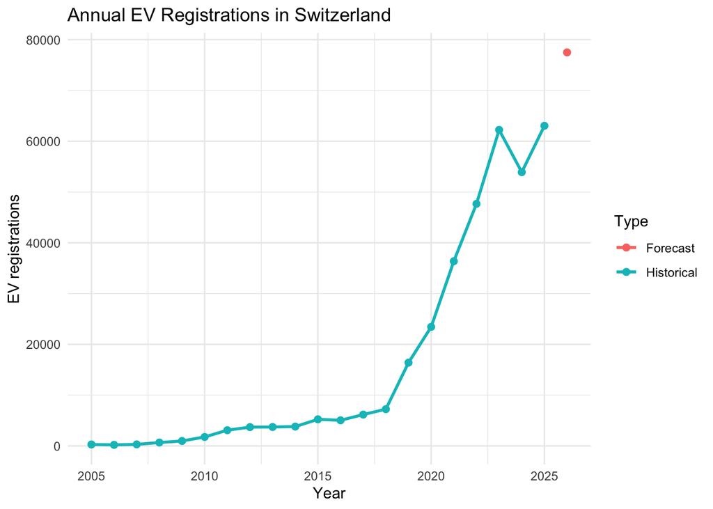

```r
annual_ev_plot <- ggplot(annual_comparison, aes(x = Year, y = EV_Registrations, color = Type)) +
  geom_line(linewidth = 1) +
  geom_point(size = 2) +
  labs(
    title = "Annual EV Registrations in Switzerland",
    x = "Year",
    y = "EV registrations"
  ) +
  theme_minimal()

# Show the plot on screen
annual_ev_plot
```

```r
# Save the plot as PNG
ggsave(
  filename = "../graphs/annual_ev_registrations.png",
  plot = annual_ev_plot,
  width = 10,
  height = 6,
  dpi = 300
)
```